# Geospatial Big Data Analytics Lab 2

Evaggelos Tsogkas 03400120

In this project we will create a spatial database using time-series data and then run queries and analyze them. The data used are weather time-series from a few selected Greek cities during the period of 1/1/2011 - 31/12/2020. The data are collected from POWER Data Access Viewer https://power.larc.nasa.gov/data-access-viewer/ and contain information about the temperature at 2 meters and the precipitation.

```python
import pandas as pd
import geopandas as gpd
from shapely.geometry import Point
import psycopg2
import folium
import matplotlib.pyplot as plt
import seaborn as sns
import plotly.express as px
import plotly.io as pio
```

## Data Preparation

The cities data contain their name, latitude and longitude.

```python
# load cities data
cities_data = pd.read_csv('data/cities.csv')
print(cities_data)
```

```
   id            name        lat       long
0   1          Athens  37.983810  23.727539
1   2    Thessaloniki  40.629269  22.947412
2   3           Patra  38.246639  21.734573
3   4          Larisa  39.643452  22.413208
4   5        Ioannina  39.665028  20.853746
5   6        Kalamata  37.036598  22.114401
6   7  Alexandroupoli  40.849136  25.879326
```

Next we convert the latitude and longitude to a geometry.

```python
# replace lat and long with geometry column
geometry = [Point(xy) for xy in zip(cities_data['long'], cities_data['lat'])]
cities_data.drop(['lat', 'long'], axis=1, inplace=True)
crs = {'init': 'epsg:4326'} # coordinate reference system
cities_data = gpd.GeoDataFrame(cities_data, crs=crs, geometry=geometry)
print(cities_data)
```

```
   id            name                     geometry
0   1          Athens   POINT (23.727539 37.98381)
1   2    Thessaloniki  POINT (22.947412 40.629269)
2   3           Patra  POINT (21.734573 38.246639)
3   4          Larisa  POINT (22.413208 39.643452)
4   5        Ioannina  POINT (20.853746 39.665028)
5   6        Kalamata  POINT (22.114401 37.036598)
6   7  Alexandroupoli  POINT (25.879326 40.849136)
```

The weather data are stored in different files for each city, so we load them all and in each dataframe we add a column with the city id, because it will be used as a foreign key in the database.

```python
# load weather data for each city
usecols = ['YEAR', 'DOY', 'T2M_MIN', 'T2M_MAX', 'T2M', 'PRECTOT'] # column names to use
athens_weather = pd.read_csv('data/athens_weather.csv', usecols = usecols, header=13)
athens_weather['city_id'] = 1
thessaloniki_weather = pd.read_csv('data/thessaloniki_weather.csv', usecols = usecols, header=13)
thessaloniki_weather['city_id'] = 2
patra_weather = pd.read_csv('data/patra_weather.csv', usecols = usecols, header=13)
patra_weather['city_id'] = 3
larisa_weather = pd.read_csv('data/larisa_weather.csv', usecols = usecols, header=13)
larisa_weather['city_id'] = 4
ioannina_weather = pd.read_csv('data/ioannina_weather.csv', usecols = usecols, header=13)
ioannina_weather['city_id'] = 5
kalamata_weather = pd.read_csv('data/kalamata_weather.csv', usecols = usecols, header=13)
kalamata_weather['city_id'] = 6
alexandroupoli_weather = pd.read_csv('data/alexandroupoli_weather.csv', usecols = usecols, header=13)
alexandroupoli_weather['city_id'] = 7
athens_weather.head()
```

|  | YEAR | DOY | T2M_MIN | T2M_MAX | T2M | PRECTOT | city_id |
| --- | --- | --- | --- | --- | --- | --- | --- |
| 0 | 2011 | 1 | 10.09 | 12.55 | 11.23 | 0.10 | 1 |
| 1 | 2011 | 2 | 11.67 | 14.14 | 13.18 | 14.64 | 1 |
| 2 | 2011 | 3 | 10.87 | 13.93 | 12.46 | 6.64 | 1 |
| 3 | 2011 | 4 | 8.93 | 11.35 | 10.20 | 0.40 | 1 |
| 4 | 2011 | 5 | 8.98 | 11.40 | 9.84 | 0.18 | 1 |

## Database

Now we will create and fill the database using the previous data. Our database will have two tables, one for the cities and one for the weather, and the last will reference the first using the city id as foreign key.

```python
# connect to postgress
connection = psycopg2.connect(database='postgres', user='user', password='user', host='localhost')
connection.autocommit = True
cursor = connection.cursor()

# create database
# We first delete it if it exists. This serves no purpose other than just running the whole notebook multiple times
cursor.execute('DROP DATABASE IF EXISTS greece_weather;')
cursor.execute('CREATE DATABASE greece_weather;')
connection.close()

# connect to the new database
connection = psycopg2.connect(database='greece_weather', user='user', password='user', host='localhost')
connection.autocommit = True
cursor = connection.cursor()
cursor.execute('CREATE EXTENSION postgis;')
```

```python
# create cities table
sql = """
    CREATE TABLE cities
    (
        id INT NOT NULL,
        name VARCHAR(40) NOT NULL,
        coordinates GEOMETRY(POINT, 4326) NOT NULL,
        PRIMARY KEY (id)
    );
    """
cursor.execute(sql)

# create weather table
sql = """
    CREATE TABLE weather
    (
        id SERIAL NOT NULL,
        year INT NOT NULL,
        doy INT NOT NULL,
        min_temperature DECIMAL(5, 2),
        max_temperature DECIMAL(5, 2),
        avg_temperature DECIMAL(5, 2),
        precipitation DECIMAL(5, 2),
        city_id INT NOT NULL,
        PRIMARY KEY (id),
        FOREIGN KEY (city_id) REFERENCES cities(id)
    );
    """
cursor.execute(sql)
```

We created the database and the tables, so now we will fill them with our data.

```python
# returns the sql statement to insert the given row into the cities table
def insert_to_cities(row):
    return "INSERT INTO cities (id, name, coordinates) VALUES (" + str(row['id']) + ", '" + str(row['name']) + "'" + \
    ", ST_GeomFromText('" + str(row['geometry'])+ "',4326));"

# returns the sql statement to insert the given row into the weather table
def insert_to_weather(row):
    return "INSERT INTO weather (year, doy, min_temperature, max_temperature, avg_temperature, precipitation, city_id) VALUES (" \
    + str(int(row['YEAR'])) + ", " + str(int(row['DOY'])) + ", " + str(row['T2M_MIN']) + ", " + str(row['T2M_MAX']) \
    + ", " + str(row['T2M']) + ", " + str(row['PRECTOT']) + ", " + str(int(row['city_id'])) + ");"
```

```python
# insert the data into the cities table
for i in cities_data.index:
    sql = insert_to_cities(cities_data.iloc[i])
    cursor.execute(sql)
```

```python
# insert the data into the weather table
for table in [athens_weather, thessaloniki_weather, patra_weather, larisa_weather, ioannina_weather, kalamata_weather,
              alexandroupoli_weather]:
    for i in table.index:
        sql = insert_to_weather(table.iloc[i])
        cursor.execute(sql)
```

## Map Visualization

The database is ready, so we will query it and visualize the weather of all cities on the map at 31/12/2020. The map is interactive and by clicking the markers we can see the information.

```python
# get data from the database
cities = gpd.GeoDataFrame.from_postgis('SELECT * FROM cities', connection, geom_col = 'coordinates')
weather = pd.io.sql.read_sql('SELECT * FROM weather', connection)
connection.close()

# add a date column to the weather table
weather['date'] = pd.to_datetime(weather['year']*1000 + weather['doy'], format='%Y%j')

# weather of cities at 31/12/2020
single_day_weather = weather[weather['date'] == pd.to_datetime('2020-12-31')]
```

```python
# folium map
m = folium.Map(location=[39.074208, 21.824312], zoom_start=6, tiles="Stamen Terrain")

# add cities weather information with the form of markers
for i in single_day_weather.index:
    city_weather = weather.iloc[i]
    city = cities[cities['id'] == city_weather['city_id']].iloc[0]
    popup_info = (city['name'] + " " + city_weather['date'].strftime('%d/%m/%Y') + '<br>'
                 'Temperature: ' + str(city_weather['avg_temperature']) + ' °C <br>'
                 'Precipitation: ' + str(city_weather['precipitation']) + ' mm')
    folium.Marker([city['coordinates'].y, city['coordinates'].x], popup=popup_info).add_to(m)
m
```

[interactive chart not shown]

## Athens Weather Time-Series

We will visualize some information about Athens weather through time. First we show the minimum, maximum and average temperature time-series, where there is a clear seasonality as we expected.

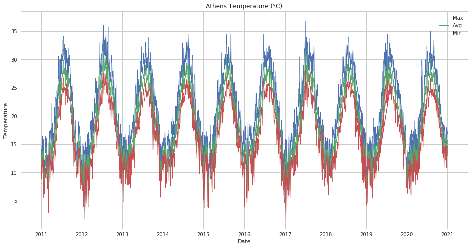

```python
# plot settings
sns.set(style='whitegrid')
pio.templates.default = "plotly_dark"
pd.plotting.register_matplotlib_converters()
plt.rcParams['figure.figsize'] = (16, 8)

# athens weather
athens_weather = weather[weather['city_id'] == cities[cities['name'] == 'Athens']['id'][0]]

# plot temperature time-series
plot_max, = plt.plot(athens_weather['date'], athens_weather['max_temperature'], linewidth=1)
plot_avg, = plt.plot(athens_weather['date'], athens_weather['avg_temperature'], linewidth=1)
plot_min, = plt.plot(athens_weather['date'], athens_weather['min_temperature'], linewidth=1)
plt.title('Athens Temperature (°C)')
plt.xlabel('Date')
plt.ylabel('Temperature')
plt.legend([plot_max, plot_avg, plot_min], ['Max', 'Avg', 'Min'])
plt.show()
```

Next we will show the average temperature by season, through the years. It seems that at 2012 there was the highest average summer temperature, as well as the lowest average winter temperature.

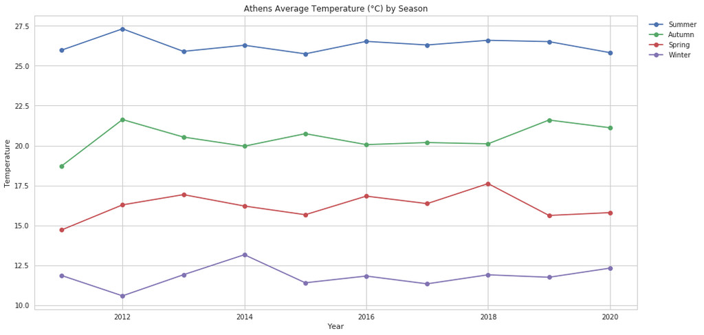

```python
# returns the season given the month number
def season(month):
    """
    Returns season based on month.
    """
    if 3 <= month <= 5:
        return 'spring'
    elif 6 <= month <= 8:
        return 'summer'
    elif 9 <= month <= 11:
        return 'autumn'
    else:
        return 'winter'

# calculate average temperature by season
pd.options.mode.chained_assignment = None
athens_weather['season'] = athens_weather['date'].dt.month.apply(season)
temp_by_season = athens_weather.groupby(['year', 'season'], as_index=False)['avg_temperature'].mean()

# plot temperature by season
plot_summer, = plt.plot(temp_by_season['year'].unique(), temp_by_season[temp_by_season['season'] == 'summer']['avg_temperature'], marker='o')
plot_autumn, = plt.plot(temp_by_season['year'].unique(), temp_by_season[temp_by_season['season'] == 'autumn']['avg_temperature'], marker='o')
plot_spring, = plt.plot(temp_by_season['year'].unique(), temp_by_season[temp_by_season['season'] == 'spring']['avg_temperature'], marker='o')
plot_winter, = plt.plot(temp_by_season['year'].unique(), temp_by_season[temp_by_season['season'] == 'winter']['avg_temperature'], marker='o')
plt.title('Athens Average Temperature (°C) by Season')
plt.xlabel('Year')
plt.ylabel('Temperature')
plt.legend([plot_summer, plot_autumn, plot_spring, plot_winter], ['Summer', 'Autumn', 'Spring', 'Winter'], bbox_to_anchor=(1.01, 1))
plt.show()
```

Now we show the precipitation time-series, where we can see some really high values standing out during 2020.

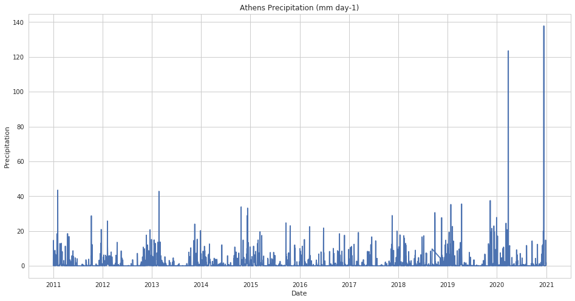

```python
# plot precipitation
plt.plot(athens_weather['date'], athens_weather['precipitation'])
plt.title('Athens Precipitation (mm day-1)')
plt.xlabel('Date')
plt.ylabel('Precipitation')
plt.show()
```

We can also see the average precipitation by month, during the years, in an interactive plot. It seems that the highest precipitation appears during winter months.

```python
# add month column
athens_weather['month'] = athens_weather['date'].dt.month

# average precipitation by month
prec_by_month = athens_weather.groupby(['year', 'month'], as_index=False)['precipitation'].mean()

fig = px.bar(prec_by_month, x='month', y='precipitation', color='year', title='Athens Precipitation (mm day-1) by Month')
fig.show()
```

[interactive chart not shown]

Finally, we show how the precipitation changes according to temperature in an interactive plot and we can see that there is higher precipitation at lower temperatures.

```python
# calculate average precipitation and temperature by month
prec_temp = athens_weather.groupby(['year', 'month'], as_index=False)['precipitation'].mean()
prec_temp['temperature'] = athens_weather.groupby(['year', 'month'], as_index=False)['avg_temperature'].mean()['avg_temperature']

fig = px.scatter(prec_temp, x='temperature', y='precipitation', color='month', title='Athens Precipitation According to Temperature')
fig.show()
```

[interactive chart not shown]